# Untitled

Manaswini

2024-04-07

## R Markdown

#Required libraries

```r
library(cluster)
library(caret)
library(dendextend)
library(knitr)
library(factoextra)
library(readr)
```

#Importing the dataset

```r
df <- read.csv("C:/Users/Winnie/Downloads/Cereals.csv")
View(df)
data <- data.frame(df[,4:16])
```

#Removing missing values of all cereals

```r
data <- na.omit(data)
```

#Data normalization using scale function

```r
data_normalize <- scale(data)
```

##TASK-1 #Using Euclidean distance to create hierarchial cluster using normalized data #Complete Linkage with hierarchial cluster

```r
Dist <- dist(data_normalize, method = "euclidean")

H_clust <- hclust(Dist, method = "complete")
```

#Dendogram Plot

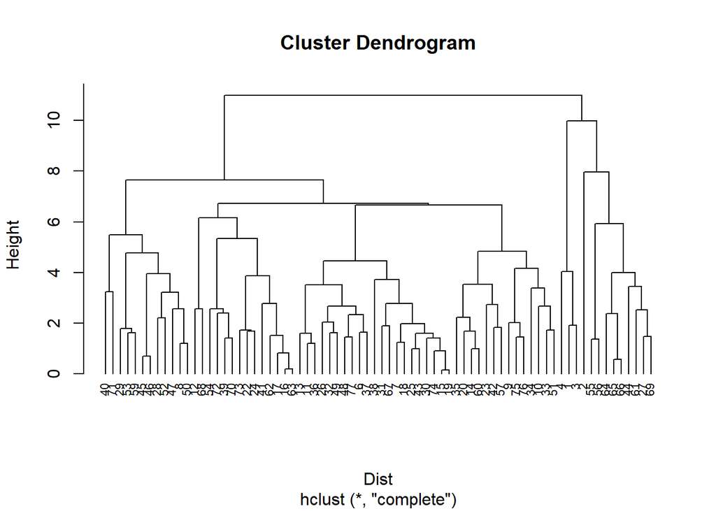

```r
plot(H_clust, cex = 0.7, hang = -1)
```

#Perform computations using AGNES clustering algorithm and with various linkage methods

```r
single_Hclust <- agnes(data_normalize, method = "single")
complete_Hclust <- agnes(data_normalize, method = "complete")
average_Hclust <- agnes(data_normalize, method = "average")
ward_Hclust <- agnes(data_normalize, method = "ward")
```

#Choosing the correct course of action

```r
print(single_Hclust$ac)
```

```
## [1] 0.6067859
```

```r
print(complete_Hclust$ac)
```

```
## [1] 0.8353712
```

```r
print(average_Hclust$ac)
```

```
## [1] 0.7766075
```

```r
print(ward_Hclust$ac)
```

```
## [1] 0.9046042
```

#ward startegy is most suitable one, as it’s value is 0.9046042

#TASK-2 #choosing the number of clusters

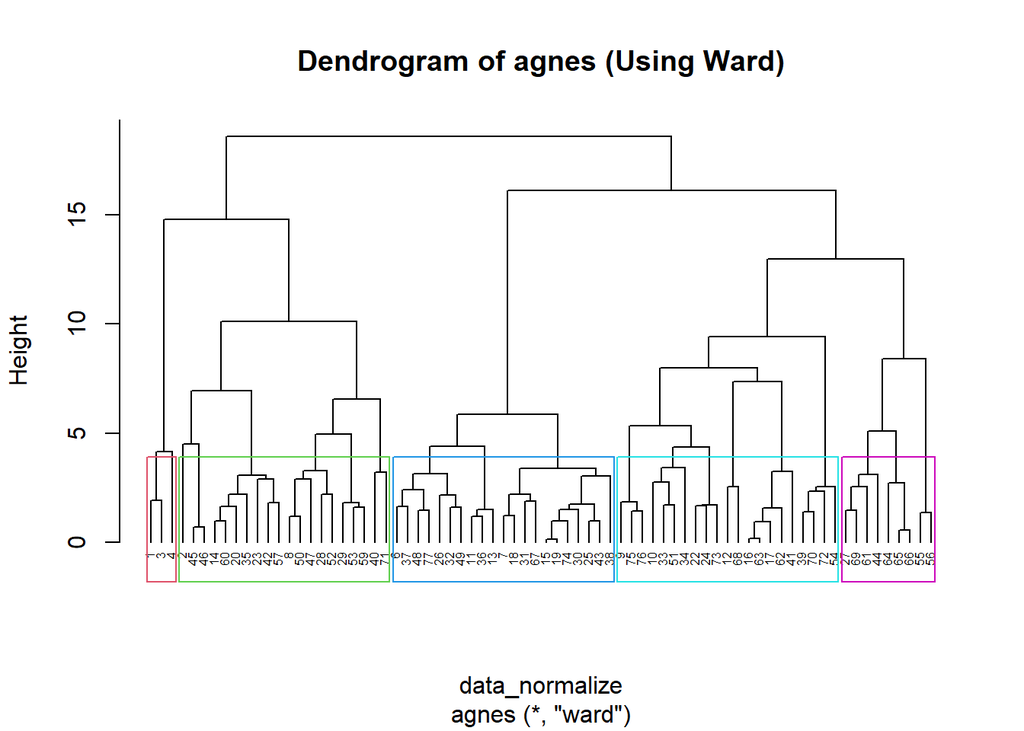

```r
pltree(ward_Hclust, cex = 0.5, hang = -1, main = "Dendrogram of agnes (Using Ward)")
rect.hclust(ward_Hclust, k = 5, border = 2:7)
```

```r
R_Group <- cutree(ward_Hclust, k=5)
D_frame_2 <- as.data.frame(cbind(data_normalize,R_Group))
```

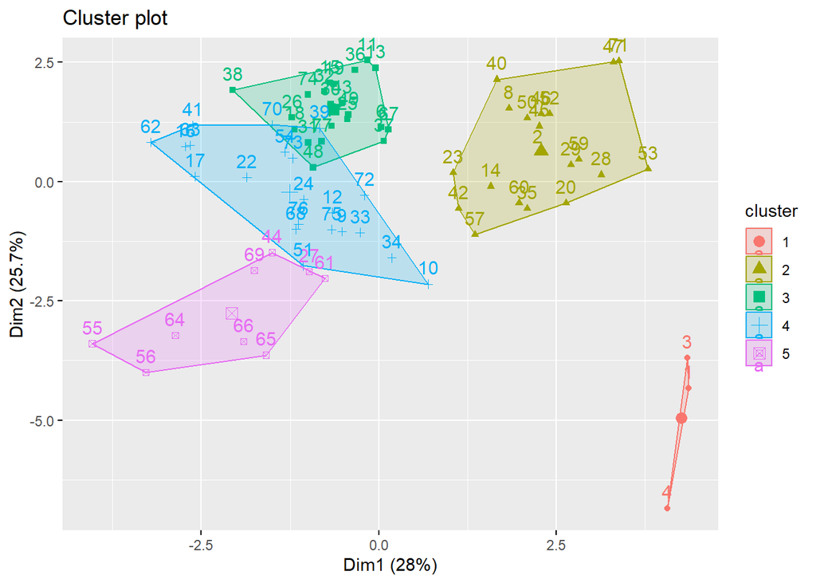

```r
fviz_cluster(list(data = D_frame_2, cluster = R_Group))
```

#From above observation 5 clusters can be choosen

#TASK-3 #Determining the stability and structure of the clusters.

```r
#creating partitions
set.seed(123)
partition_one <- data[1:55,]
partition_two <- data[56:74,]
```

#Performing Hierarchical Clustering while considering k = 5. Compute with AGNES and with different linkage methods for training dataset

```r
single_df <- agnes(scale(partition_one), method = "single")
complete_df <- agnes(scale(partition_one), method = "complete")
average_df <- agnes(scale(partition_one), method = "average")
ward_df <- agnes(scale(partition_one), method = "ward")
cbind(single=single_df$ac , complete=complete_df$ac , average= average_df$ac , ward= ward_df$ac)
```

```
##         single  complete   average      ward
## [1,] 0.6564842 0.8120228 0.7449303 0.8808195
```

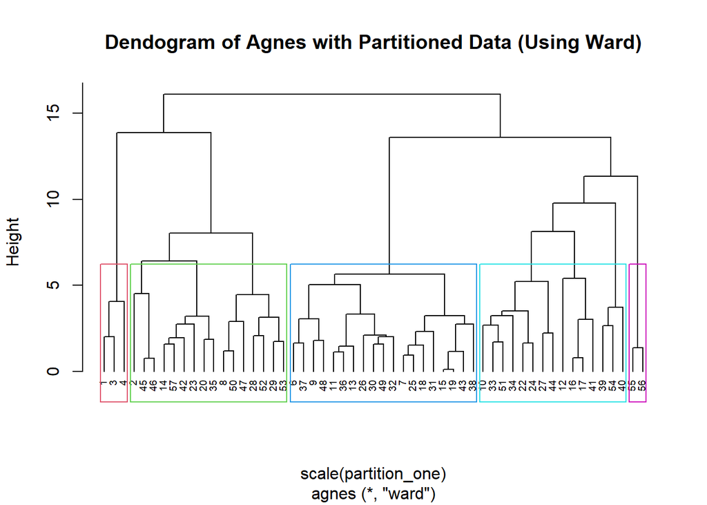

```r
pltree(ward_df, cex = 0.6, hang = -1, main = "Dendogram of Agnes with Partitioned Data (Using Ward)")
rect.hclust(ward_df, k = 5, border = 2:7)
```

```r
cut_2 <- cutree(ward_df, k = 5)
```

#Calculating the centroids

```r
data_result <- as.data.frame(cbind(partition_one, cut_2))
data_result[data_result$cut_2==1,]
```

```
##   calories protein fat sodium fiber carbo sugars potass vitamins shelf weight
## 1       70       4   1    130    10     5      6    280       25     3      1
## 3       70       4   1    260     9     7      5    320       25     3      1
## 4       50       4   0    140    14     8      0    330       25     3      1
##   cups   rating cut_2
## 1 0.33 68.40297     1
## 3 0.33 59.42551     1
## 4 0.50 93.70491     1
```

```r
centroid_1 <- colMeans(data_result[data_result$cut_2==1,])
data_result[data_result$cut_2==2,]
```

```
##    calories protein fat sodium fiber carbo sugars potass vitamins shelf weight
## 2       120       3   5     15   2.0   8.0      8    135        0     3   1.00
## 8       130       3   2    210   2.0  18.0      8    100       25     3   1.33
## 14      110       3   2    140   2.0  13.0      7    105       25     3   1.00
## 20      110       3   3    140   4.0  10.0      7    160       25     3   1.00
## 23      100       2   1    140   2.0  11.0     10    120       25     3   1.00
## 28      120       3   2    160   5.0  12.0     10    200       25     3   1.25
## 29      120       3   0    240   5.0  14.0     12    190       25     3   1.33
## 35      120       3   3     75   3.0  13.0      4    100       25     3   1.00
## 42      100       4   2    150   2.0  12.0      6     95       25     2   1.00
## 45      150       4   3     95   3.0  16.0     11    170       25     3   1.00
## 46      150       4   3    150   3.0  16.0     11    170       25     3   1.00
## 47      160       3   2    150   3.0  17.0     13    160       25     3   1.50
## 50      140       3   2    220   3.0  21.0      7    130       25     3   1.33
## 52      130       3   2    170   1.5  13.5     10    120       25     3   1.25
```

[output cut: 19 more lines]

```r
centroid_2 <- colMeans(data_result[data_result$cut_2==2,])
data_result[data_result$cut_2==3,]
```

```
##    calories protein fat sodium fiber carbo sugars potass vitamins shelf weight
## 6       110       2   2    180   1.5  10.5     10     70       25     1      1
## 7       110       2   0    125   1.0  11.0     14     30       25     2      1
## 9        90       2   1    200   4.0  15.0      6    125       25     1      1
## 11      120       1   2    220   0.0  12.0     12     35       25     2      1
## 13      120       1   3    210   0.0  13.0      9     45       25     2      1
## 15      110       1   1    180   0.0  12.0     13     55       25     2      1
## 18      110       1   0     90   1.0  13.0     12     20       25     2      1
## 19      110       1   1    180   0.0  12.0     13     65       25     2      1
## 25      110       2   1    125   1.0  11.0     13     30       25     2      1
## 26      110       1   0    200   1.0  14.0     11     25       25     1      1
## 30      110       1   1    135   0.0  13.0     12     25       25     2      1
## 31      100       2   0     45   0.0  11.0     15     40       25     1      1
## 32      110       1   1    280   0.0  15.0      9     45       25     2      1
## 36      120       1   2    220   1.0  12.0     11     45       25     2      1
```

[output cut: 25 more lines]

```r
centroid_3 <- colMeans(data_result[data_result$cut_2==3,])
data_result[data_result$cut_2==4,]
```

```
##    calories protein fat sodium fiber carbo sugars potass vitamins shelf weight
## 10       90       3   0    210     5    13      5    190       25     3    1.0
## 12      110       6   2    290     2    17      1    105       25     1    1.0
## 16      110       2   0    280     0    22      3     25       25     1    1.0
## 17      100       2   0    290     1    21      2     35       25     1    1.0
## 22      110       2   0    220     1    21      3     30       25     3    1.0
## 24      100       2   0    190     1    18      5     80       25     3    1.0
## 27      100       3   0      0     3    14      7    100       25     2    1.0
## 33      100       3   1    140     3    15      5     85       25     3    1.0
## 34      110       3   0    170     3    17      3     90       25     3    1.0
## 39      110       2   1    170     1    17      6     60      100     3    1.0
## 40      140       3   1    170     2    20      9     95      100     3    1.3
## 41      110       2   1    260     0    21      3     40       25     2    1.0
## 44      100       4   1      0     0    16      3     95       25     2    1.0
## 51       90       3   0    170     3    18      2     90       25     3    1.0
```

[output cut: 17 more lines]

```r
centroid_4 <- colMeans(data_result[data_result$cut_2==4,])
centroids <- rbind(centroid_1, centroid_2, centroid_3, centroid_4)
x2 <- as.data.frame(rbind(centroids[,-14], partition_two))
```

#figuring out the distance

```r
Dist_1 <- get_dist(x2)
Matrix_1 <- as.matrix(Dist_1)
dataframe1 <- data.frame(data=seq(1,nrow(partition_two),1), Clusters = rep(0,nrow(partition_two)))
for(i in 1:nrow(partition_two))
  {dataframe1[i,2] <- which.min(Matrix_1[i+4, 1:4])}
dataframe1
```

```
##    data Clusters
## 1     1        1
## 2     2        2
## 3     3        2
## 4     4        3
## 5     5        4
## 6     6        2
## 7     7        2
## 8     8        2
## 9     9        3
## 10   10        4
## 11   11        2
## 12   12        4
## 13   13        2
## 14   14        4
## 15   15        4
## 16   16        3
## 17   17        4
## 18   18        4
## 19   19        3
```

```r
cbind(D_frame_2$R_Group[56:74], dataframe1$Clusters)
```

```
##       [,1] [,2]
##  [1,]    2    1
##  [2,]    2    2
##  [3,]    5    2
##  [4,]    4    3
##  [5,]    4    4
##  [6,]    5    2
##  [7,]    5    2
##  [8,]    5    2
##  [9,]    3    3
## [10,]    4    4
## [11,]    5    2
## [12,]    4    4
## [13,]    2    2
## [14,]    4    4
## [15,]    4    4
## [16,]    3    3
## [17,]    4    4
## [18,]    4    4
## [19,]    3    3
```

```r
table(D_frame_2$R_Group[56:74] == dataframe1$Clusters)
```

```
##
## FALSE  TRUE
##     7    12
```

#From above observation we can conclude that the model is stable as we got 12 TRUE and 7 FALSE

#TASK-4 #The elementary public schools would like to choose a set of cereals to include in their daily cafeterias. Every day a different cereal is offered, but all cereals should support a healthy diet. For this goal, you are requested to find a cluster of “healthy cereals.” Should the data be normalized? If not, how should they be used in the cluster analysis?

```r
Health_data <- df
Health_data_RD <- na.omit(Health_data)
clust <- cbind(Health_data_RD, R_Group)
clust[clust$R_Group==1,]
```

```
##                        name mfr type calories protein fat sodium fiber carbo
## 1                 100%_Bran   N    C       70       4   1    130    10     5
## 3                  All-Bran   K    C       70       4   1    260     9     7
## 4 All-Bran_with_Extra_Fiber   K    C       50       4   0    140    14     8
##   sugars potass vitamins shelf weight cups   rating R_Group
## 1      6    280       25     3      1 0.33 68.40297       1
## 3      5    320       25     3      1 0.33 59.42551       1
## 4      0    330       25     3      1 0.50 93.70491       1
```

```r
clust[clust$R_Group==2,]
```

```
##                                      name mfr type calories protein fat sodium
## 2                       100%_Natural_Bran   Q    C      120       3   5     15
## 8                                 Basic_4   G    C      130       3   2    210
## 14                               Clusters   G    C      110       3   2    140
## 20                     Cracklin'_Oat_Bran   K    C      110       3   3    140
## 23                 Crispy_Wheat_&_Raisins   G    C      100       2   1    140
## 28 Fruit_&_Fibre_Dates,_Walnuts,_and_Oats   P    C      120       3   2    160
## 29                          Fruitful_Bran   K    C      120       3   0    240
## 35                     Great_Grains_Pecan   P    C      120       3   3     75
## 40                 Just_Right_Fruit_&_Nut   K    C      140       3   1    170
## 42                                   Life   Q    C      100       4   2    150
## 45       Muesli_Raisins,_Dates,_&_Almonds   R    C      150       4   3     95
## 46      Muesli_Raisins,_Peaches,_&_Pecans   R    C      150       4   3    150
## 47                   Mueslix_Crispy_Blend   K    C      160       3   2    150
## 50              Nutri-Grain_Almond-Raisin   K    C      140       3   2    220
```

[output cut: 27 more lines]

```r
clust[clust$R_Group==3,]
```

```
##                       name mfr type calories protein fat sodium fiber carbo
## 6  Apple_Cinnamon_Cheerios   G    C      110       2   2    180   1.5  10.5
## 7              Apple_Jacks   K    C      110       2   0    125   1.0  11.0
## 11            Cap'n'Crunch   Q    C      120       1   2    220   0.0  12.0
## 13   Cinnamon_Toast_Crunch   G    C      120       1   3    210   0.0  13.0
## 15             Cocoa_Puffs   G    C      110       1   1    180   0.0  12.0
## 18               Corn_Pops   K    C      110       1   0     90   1.0  13.0
## 19           Count_Chocula   G    C      110       1   1    180   0.0  12.0
## 25             Froot_Loops   K    C      110       2   1    125   1.0  11.0
## 26          Frosted_Flakes   K    C      110       1   0    200   1.0  14.0
## 30          Fruity_Pebbles   P    C      110       1   1    135   0.0  13.0
## 31            Golden_Crisp   P    C      100       2   0     45   0.0  11.0
## 32          Golden_Grahams   G    C      110       1   1    280   0.0  15.0
## 36        Honey_Graham_Ohs   Q    C      120       1   2    220   1.0  12.0
## 37      Honey_Nut_Cheerios   G    C      110       3   1    250   1.5  11.5
```

[output cut: 29 more lines]

```r
clust[clust$R_Group==4,]
```

```
##                           name mfr type calories protein fat sodium fiber carbo
## 9                    Bran_Chex   R    C       90       2   1    200     4    15
## 10                 Bran_Flakes   P    C       90       3   0    210     5    13
## 12                    Cheerios   G    C      110       6   2    290     2    17
## 16                   Corn_Chex   R    C      110       2   0    280     0    22
## 17                 Corn_Flakes   K    C      100       2   0    290     1    21
## 22                     Crispix   K    C      110       2   0    220     1    21
## 24                 Double_Chex   R    C      100       2   0    190     1    18
## 33           Grape_Nuts_Flakes   P    C      100       3   1    140     3    15
## 34                  Grape-Nuts   P    C      110       3   0    170     3    17
## 39 Just_Right_Crunchy__Nuggets   K    C      110       2   1    170     1    17
## 41                         Kix   G    C      110       2   1    260     0    21
## 51           Nutri-grain_Wheat   K    C       90       3   0    170     3    18
## 54                  Product_19   K    C      100       3   0    320     1    20
## 62                   Rice_Chex   R    C      110       1   0    240     0    23
```

[output cut: 29 more lines]

```r
mean(clust[clust$R_Group==1,"rating"])
```

```
## [1] 73.84446
```

```r
mean(clust[clust$R_Group==2,"rating"])
```

```
## [1] 38.26161
```

```r
mean(clust[clust$R_Group==3,"rating"])
```

```
## [1] 28.84825
```

```r
mean(clust[clust$R_Group==4,"rating"])
```

```
## [1] 46.46513
```

#From the above observation we can see that cluster 1 has the highest value #Hence Group 1 can be considered as the cluster for healthy diet